# Computational Biology (BIO 381)

Emma Gagne

Spring 2021

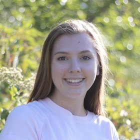

This is where you will find all projects for Computational Biology, BIOL 381. Homework assignments are posted below. Welcome to my page!

# Research Page

[My Webpage](https://emmagagne.github.io/EmmaGagne)

# Weekly Homework

[Homework 02](https://emmagagne.github.io/Homework_02/)  
Linking a web page to local repository.

[Homework 03](https://emmagagne.github.io/Homework_03/)  
Regular expression puzzles using the find and search feature in BBEdit.

Homework 04, Typora  
Learning how to use a Typora document.

Homework 04, Letter Template  
Learning how to use Sweave in order to create a letter template.

Homework 04, Presentation Template  
Using Sweave yet again to create a presentation template.

Homework 05  
Playing with vectors.

Homework 06  
Playing with matrices and data frames.

Homework 07  
Simulating and fitting data distributions, creating histograms.

Homework 08  
Creating a fake data set using research from my lab.

Homework 09  
Using what we learned in controlled structure programming to re-organize and design homework 08.

Homework 10  
Using for loops, subsetting, comparing randomization tests to stasticial analyses.

Homework 11  
Batch processing.

Homework 12  
Using ggplot to create graphs for my own data. Experimenting with different themes, theme base sizes, aesthetics, mappings, and faceting.